# MSR Praktikum Pertemuan 1

Fatih Avicenna Hizir

2026-01-29

## 0.1 SOAL 1

Dalam sebuah kelompok berisi 10 orang, terdapat 4 orang yang mahir dan 6 orang pemula. Sebuah tim dengan 5 anggota akan dipilih secara acak.

1. Buat simulasi pemilihan tim sebanyak 1000 kali.
2. Hitung rata-rata jumlah anggota mahir dalam tim berdasarkan simulasi tersebut.
3. Gambarkan barchart hasil simulasi.

```r
# Menetapkan seed agar hasil simulasi selalu sama (berdasarkan NIM = 020)
set.seed(020)
# *catatan set.seed digunakan agar proses random menghasilkan nilai yang sama setiap dijalankan

# Membuat fungsi simulasi pemilihan tim
SimulasiTim <- function() {
  # *catatan fungsi ini digunakan untuk mensimulasikan satu kali pemilihan tim

  kelompok <- c(rep("Mahir", 4), rep("Pemula", 6))
  # membuat vektor berisi 10 orang, terdiri dari 4 orang Mahir dan 6 orang Pemula

  tim <- sample(kelompok, 5, replace = FALSE)
  # memilih 5 orang secara acak tanpa pengembalian dari kelompok

  sum(tim == "Mahir")
  # menghitung jumlah anggota bertipe "Mahir" dalam tim terpilih
}

# Menjalankan simulasi sebanyak 1000 kali
hasil <- replicate(1000, SimulasiTim())


# Menghitung rata-rata jumlah anggota mahir
rata_rata_mahir <- mean(hasil)

# Menampilkan hasil rata-rata ke layar
cat("Rata-rata jumlah anggota mahir dalam tim:", rata_rata_mahir, "\n")
```

```
## Rata-rata jumlah anggota mahir dalam tim: 2.014
```

### 0.1.1 Visualisasi Soal 1

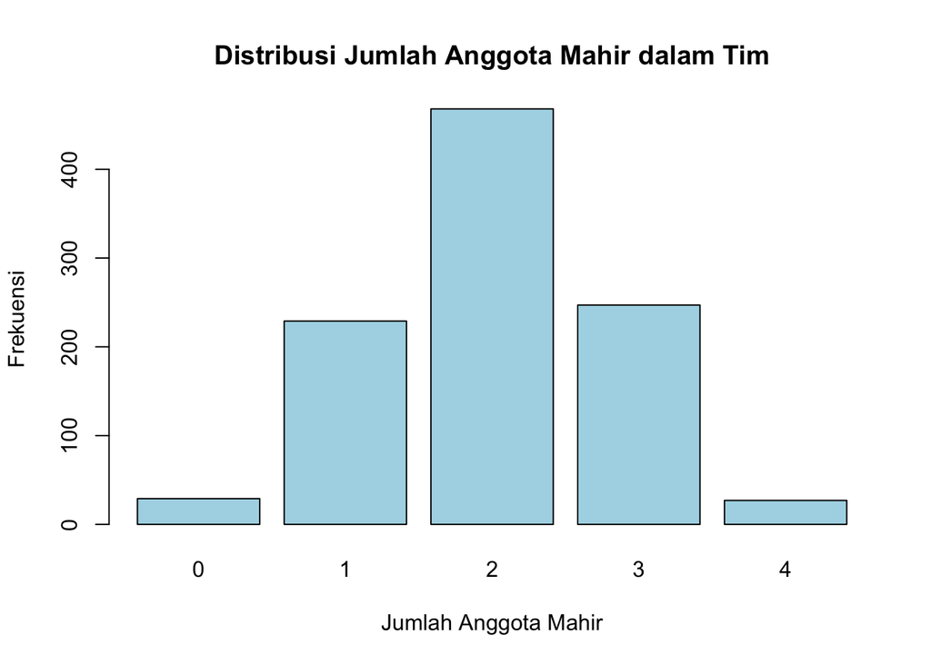

```r
# Membuat bar chart dari hasil simulasi
barplot(
  table(hasil),
  main = "Distribusi Jumlah Anggota Mahir dalam Tim",
  xlab = "Jumlah Anggota Mahir",
  ylab = "Frekuensi",
  col = "lightblue"
)
```

```r
# *catatan barplot digunakan untuk menampilkan distribusi frekuensi jumlah anggota Mahir
```

Barplot menunjukkan bahwa jumlah anggota **mahir sebanyak 2 orang** paling sering muncul dalam tim hasil simulasi. Hal ini sesuai dengan proporsi anggota mahir dalam kelompok awal, sehingga jumlah tersebut menjadi yang paling mungkin terjadi. Kejadian dengan anggota mahir sangat sedikit atau sangat banyak relatif jarang muncul.

## 0.2 SOAL 2

Dalam sebuah lotere, terdapat 100 tiket dengan nomor dari 1 hingga 100. Dari total tiket, hanya 10 tiket yang merupakan tiket pemenang.

1. Simulasikan pengambilan tiket secara acak sebanyak 3 kali tanpa pengembalian.
2. Tentukan apakah salah satu tiket yang diambil adalah tiket pemenang.
3. Ulangi simulasi sebanyak 1000 kali, hitung peluang mendapatkan setidaknya 1 tiket pemenang.

```r
# Menetapkan seed agar hasil simulasi konsisten (berdasarkan NIM = 020)
set.seed(020)
# *catatan set.seed digunakan agar hasil pengambilan acak tetap sama setiap dijalankan

# Membuat fungsi simulasi pengambilan tiket lotere
SimulasiLotere <- function() {
  # *catatan fungsi ini mensimulasikan satu kali pengambilan 3 tiket

  tiket <- c(rep("Pemenang", 10), rep("Biasa", 90))
  # membuat vektor tiket dengan 10 tiket pemenang dan 90 tiket biasa

  ambil <- sample(tiket, 3, replace = FALSE)
  # mengambil 3 tiket secara acak tanpa pengembalian

  any(ambil == "Pemenang")
  # memeriksa apakah terdapat minimal satu tiket pemenang
}

# Menentukan jumlah simulasi
n_simulasi <- 1000
# *catatan simulasi diulang sebanyak 1000 kali untuk mendekati peluang sebenarnya

# Menjalankan simulasi sebanyak 1000 kali
hasil_simulasi <- replicate(n_simulasi, SimulasiLotere())
# *catatan menyimpan hasil TRUE/FALSE dari tiap simulasi

# Menghitung peluang mendapatkan setidaknya satu tiket pemenang
peluang_menang <- mean(hasil_simulasi)
# *catatan rata-rata nilai logika TRUE/FALSE merepresentasikan peluang kejadian

# Menampilkan hasil peluang
cat("Peluang mendapatkan setidaknya 1 tiket pemenang:", peluang_menang, "\n")
```

```
## Peluang mendapatkan setidaknya 1 tiket pemenang: 0.256
```

## 0.3 SOAL 3

Sebuah permainan domino menggunakan kartu bernomor 1 hingga 12. Saat kartu pertama diambil, kartu kedua runtuh jika nomor kartu pertama adalah kelipatan dari nomor kartu kedua.

1. Buat simulasi mengambil 2 kartu acak dari tumpukan (tanpa pengembalian).
2. Tentukan apakah kartu kedua akan runtuh.
3. Ulangi simulasi sebanyak 500 kali, hitung berapa kali kartu kedua runtuh, dan hitung peluang runtuhnya kartu kedua.

```r
# Menetapkan seed agar hasil simulasi konsisten (berdasarkan NIM = 020)
set.seed(020)

# Membuat fungsi simulasi permainan domino
SimulasiDomino <- function() {
  # *catatan fungsi ini mensimulasikan satu kali pengambilan dua kartu

  kartu <- 1:12
  # vektor kartu domino bernomor 1 sampai 12

  ambil <- sample(kartu, 2, replace = FALSE)
  # mengambil dua kartu secara acak tanpa pengembalian

  kartu_pertama <- ambil[1]
  # menyimpan nilai kartu pertama

  kartu_kedua <- ambil[2]
  # menyimpan nilai kartu kedua

  kartu_pertama %% kartu_kedua == 0
  # bernilai TRUE jika kartu pertama kelipatan kartu kedua
}

# Menentukan jumlah simulasi
n_simulasi <- 500
# jumlah pengulangan simulasi

# Menjalankan simulasi
hasil_simulasi <- replicate(n_simulasi, SimulasiDomino())
# menyimpan hasil runtuh (TRUE) atau tidak runtuh (FALSE)

# Menghitung jumlah kartu kedua yang runtuh
jumlah_runtuh <- sum(hasil_simulasi)
# menghitung total kejadian kartu kedua runtuh

# Menghitung peluang kartu kedua runtuh
peluang_runtuh <- mean(hasil_simulasi)
# menghitung peluang runtuh sebagai proporsi kejadian runtuh

# Menampilkan hasil
cat("Jumlah kartu kedua runtuh:", jumlah_runtuh, "\n")
```

```
## Jumlah kartu kedua runtuh: 76
```

```r
# catatan/penjelasan: menampilkan total kejadian runtuh dari seluruh simulasi

cat("Peluang kartu kedua runtuh:", peluang_runtuh, "\n")
```

```
## Peluang kartu kedua runtuh: 0.152
```

```r
# catatan/penjelasan: menampilkan peluang kartu kedua runtuh
```